# Analysis of Variance (ANOVA)

March 23, 2020

## Analysis of Variance (ANOVA)

The goal of ANOVA is to test whether there is a discernible difference between the means of three or more groups.

#### Example

Is there a difference between washing hands with: water only, regular soap, antibacterial soap (ABS), and antibacterial spray (AS)?

- Each tested with 8 replications
- Treatments randomly assigned

For ANOVA:

- The means all differ.
- Is this just natural variability?
- Null hypothesis: All the means are the same.
- Alternative hypothesis: The means are not all the same.

## Hand Washing Comparison

```r
hand <- read.csv('../course_data/Hand_washing.csv')
head(hand, n = 10)
```

```
##    Bacterial.Counts             Method
## 1                74              Water
## 2                84               Soap
## 3                70 Antibacterial Soap
## 4                51      Alcohol Spray
## 5               135              Water
## 6                51               Soap
## 7               164 Antibacterial Soap
## 8                 5      Alcohol Spray
## 9               102              Water
## 10              110               Soap
```

## Hand Washing Comparison

```r
(grand.mean <- mean(hand$Bacterial.Counts))
```

```
## [1] 88.25
```

```r
hands.tab <- describeBy(hand$Bacterial.Counts, group = hand$Method, mat = TRUE)[,c(2,4,5,6)]
hands.tab$Var <- hands.tab$sd^2
print(hands.tab, row.names=FALSE)
```

```
##              group1 n  mean       sd       Var
##       Alcohol Spray 8  37.5 26.55991  705.4286
##  Antibacterial Soap 8  92.5 41.96257 1760.8571
##                Soap 8 106.0 46.95895 2205.1429
##               Water 8 117.0 31.13106  969.1429
```

## Hand Washing Comparison

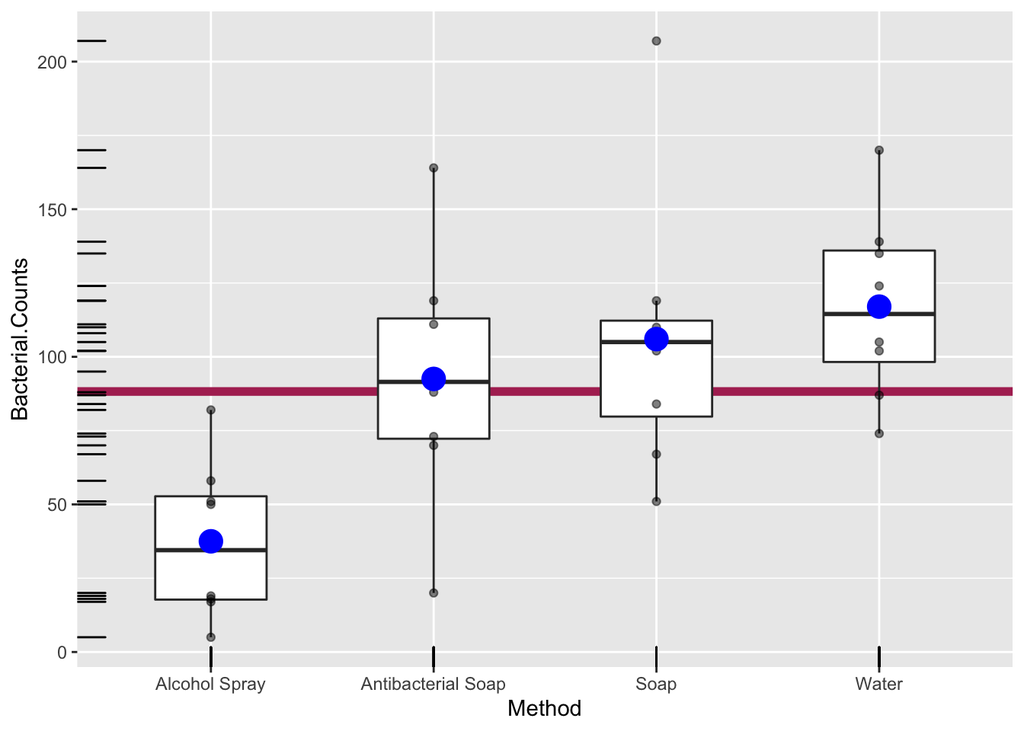

## Is washing type all the same?

ANOVA is used to assess whether the mean of the outcome variable is different for different levels of a categorical variable.

\(H_0\): The mean outcome is the same across all categories,

\[\mu_1 = \mu_2 = \mu_3 = \mu_4\]

where \(u_i\) represents the mean of the outcome for observations in categori *i*.

\(H_A\): At least one mean is different than the others.

We will use a new test statistic, *F*:

\[F = \frac{\text{variability between groups}}{\text{variability within groups}}\]

## Conditions

1. The observations should be independent within and between groups
   - If the data are a simple random sample from less than 10% of the population, this condition is satisfied.
   - Carefully consider whether the data may be independent (e.g. no pairing).
   - Always important, but sometimes difficult to check.
2. The observations within each group should be nearly normal.
   - Especially important when the sample sizes are small. How do we check for normality?
3. The variability across the groups should be about equal (Equal Variance Assumption).
   - Especially important when the sample sizes differ between groups.

## Degrees of Freedom

With ANOVA, we have different degrees of freedom depending on which component we are looking at:

- groups: \(df_G = k - 1\)
- total: \(df_T = n - 1\)
- error: \(df_E = df_T - df_G\)

For our handwashing example, our degrees of freedom are:

- \(df_G = 4 - 1 = 3\)
- \(df_T = 32 - 1 = 31\)
- \(df_E = 31 - 3 = 28\)

## Sum of Squares Between Groups \(SS_G\)

Measures the variablity between groups.

\[SS_G = \sum_{i=0}^{k}n_i(\bar{x_i}-\bar{x})^2\]

where \(n_i\) is each group size, \(\bar{x_i}\) is the average for each group, \(\bar{x}\) is the overall (grand) mean.

```r
hands.tab$SSG_part <- hands.tab$n * (hands.tab$mean - grand.mean)^2
(SSG <- sum(hands.tab$SSG_part))
```

```
## [1] 29882
```

## Sum of Squares Total \(SS_T\)

Measures the total variability:

\[SS_T = \sum_{i=0}^{n}(x_i-\bar{x})^2\]

where \(x_i\) represents each observation in the dataset.

```r
(SST <- sum( (hand$Bacterial.Counts - grand.mean)^2 ))
```

```
## [1] 69366
```

## Sum of Squares Error \(SS_E\)

Measures the variability within groups:

\[SS_E = SS_T - SS_G\]

```r
(SSE <- SST - SSG)
```

```
## [1] 39484
```

## Mean Square

Mean square is calculated as the sum of squares divided by the degrees of freedom.

\[MS_G = \frac{SS_G}{k - 1}\]

```r
(MSG <- SSG / 3)
```

```
## [1] 9960.667
```

```r
(MSE <- SSE / 28)
```

```
## [1] 1410.143
```

## Test Statistic, F value

The F statistic is the ratio of the between group and within group variability:

\[F = \frac{\text{variability between groups}}{\text{variability within groups}} = \frac{MS_G}{MS_E}\]

```r
MSG / MSE
```

```
## [1] 7.063587
```

## Comparing \(MS_G\) (between) and \(MS_E\) (within)

\(MS_G\)

- Estimates \(s^2\) if \(H_0\) is true
- Should be larger than \(s^2\) if \(H_0\) is false

\(MS_E\)

- Estimates \(s^2\) whether \(H_0\) is true or not
- If \(H_0\) is true, both close to \(s^2\), so \(MS_G\) is close to \(MS_E\)

Comparing

- If \(H_0\) is true, \(\frac{MS_G}{MS_E}\) should be close to 1
- If \(H_0\) is false, \(\frac{MS_G}{MS_E}\) tends to be > 1

## The F-Distribution

- How do we tell whether \(\frac{MS_G}{MS_E}\) is larger enough to not be due just to random chance
- \(\frac{MS_G}{MS_E}\) follows the F-Distribution
  - Numerator df: k - 1 (k = number of groups)
  - Denominator df: k(n - 1)
  - n = # observations in each group
- \(F = \frac{MS_G}{MS_E}\) is called the F-Statistic.

A Shiny App by Dr. Dudek to explore the F-Distribution: https://shiny.rit.albany.edu/stat/fdist/

## The F-Distribution (cont.)

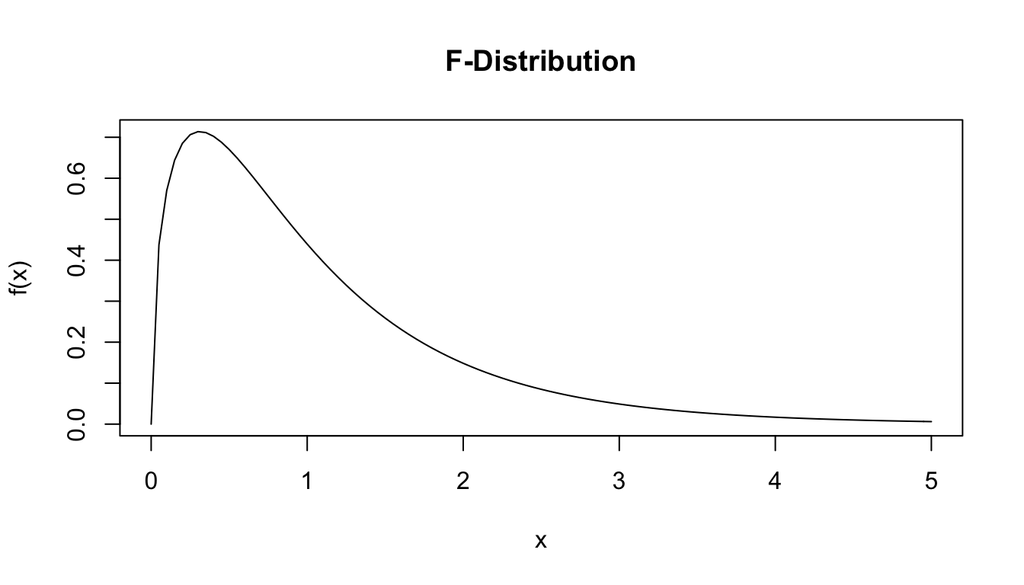

```r
df.numerator <- 4 - 1
df.denominator <- 4 * (8 - 1)
plot(function(x)(df(x,df1=df.numerator,df2=df.denominator)),
     xlim=c(0,5), xlab='x', ylab='f(x)', main='F-Distribution')
```

## Back to Bacteria

- \(MS_G = 9960.64\)
- \(MS_E = 1410.14\)
- Numerator df = 4 - 1 = 3
- Denominator df = 4(8 - 1) = 28.

```r
(f.stat <- 9960.64 / 1410.14)
```

```
## [1] 7.063582
```

```r
1 - pf(f.stat, 3, 28)
```

```
## [1] 0.001111464
```

**P-value for \(F_{3,28} = 0.0011\)**

The p-value is the probability of at least as large a ratio between the “between group” and “within group” variability, if in fact the means of all groups are equal. It’s calculated as the area under the F distribution, with degrees of freedom \(df_G\) and \(df_E\), above the observed F statistic.

## ANOVA in R

```r
aov.out <- aov(Bacterial.Counts ~ Method, data=hand)
summary(aov.out)
```

```
##             Df Sum Sq Mean Sq F value  Pr(>F)
## Method       3  29882    9961   7.064 0.00111 **
## Residuals   28  39484    1410
## ---
## Signif. codes:  0 '***' 0.001 '**' 0.01 '*' 0.05 '.' 0.1 ' ' 1
```

## What Next?

- P-value large -> Nothing left to say
- P-value small -> Which means are large and which means are small?
- We can perform a t-test to compare two of them.
- We assumed the standard deviations are all equal.
- Use \(s_p\), for pooled standard deviations.
- Use the Students t-model, df = N - k.
- If we wanted to do a t-test for each pair:
  - P(Type I Error) = 0.05 for each test.
  - Good chance at least one will have a Type I error.
- **Bonferroni to the rescue!**

## Bonferroni Adjustments

We typically set our alpha level to 5% (i.e. 95% confidence). Doing a paired analysis, the critical value using the *t* distribution would be:

```r
(cv <- qt(0.05 / 2, 15))
```

```
## [1] -2.13145
```

However, if we want to do K paired comparisons but maintaine the same 95% confidence (i.e. Type I error rate), we need to split that 5% across each test (i.e. \(\frac{0.05}{K}\)). If there are *k* groups, then all possible pairs can be compared using:

\[K = \frac{k(k-1)}{2}\]

For our hand resulting example, this would now be our critical value from the *t* distribution:

```r
n.tests <- (4 * (4-1)) / 2
(bcv <- qt((0.05 / n.tests) / 2, 15))
```

```
## [1] -3.036283
```

## Hand Washing Comparison (with Bonferroni CIs)

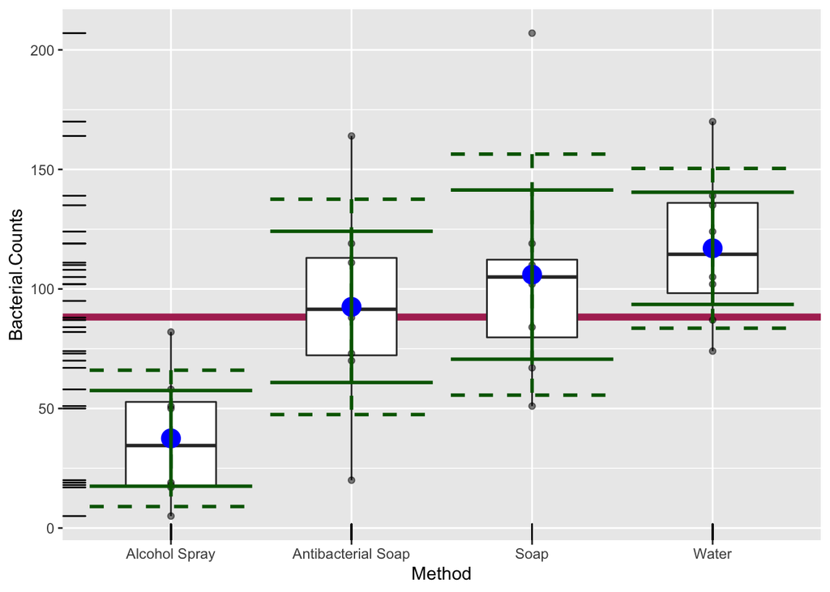